# R Genomics: factors and data frames

# R Basics continued - factors and data frames

Working with spreadsheets (tabular data)

Importing tabular data into R

There are several ways to import data into R.

For our purpose here, we will focus on using the tools every R installation comes with (so called “base” R)

to import a comma-delimited file containing the results of our variant calling workflow.

We will need to load the sheet using a function called read.csv().

```r
?read.csv()
```

Now, let’s read in the file combined_tidy_vcf.csv

```r
# read in a CSV file and save it as 'variants'
variants <- read.csv("rawdata/combined_tidy_vcf.csv")
```

[output not shown]

Use View() function to bring up inbuilt data frame viewer

```r
View(variants)
```

[output not shown]

## Summarizing and determining the structure of a data frame.

A data frame is the standard way in R to store tabular data.

A data fame could also be thought of as a collection of vectors, all of which have the same length.

Using only two functions, we can learn a lot about out data frame

including some summary statistics as well as well as the “structure” of the data frame.

Let’s examine what each of these functions can tell us:

```r
#summary(variants)
```

skim it

```r
skimr::skim(variants)
```

```
Skim summary statistics
 n obs: 801
 n variables: 29

── Variable type:factor ──────────────────────────────────────────────────────────────────────────────────────────
      variable missing complete   n n_unique                         top_counts ordered
           ALT       0      801 801       57     A: 211, T: 203, G: 154, C: 139   FALSE
         CHROM       0      801 801        1                    CP0: 801, NA: 0   FALSE
           DP4       0      801 801      217 0,0: 25, 0,0: 22, 0,0: 21, 0,0: 21   FALSE
 gt_GT_alleles       0      801 801       57     A: 211, T: 203, G: 154, C: 139   FALSE
         gt_PL       0      801 801      206   255: 280, 223: 8, 237: 8, 179: 7   FALSE
         Indiv       0      801 801        3  /ho: 766, /ho: 25, /ho: 10, NA: 0   FALSE
           REF       0      801 801       59     G: 214, C: 198, A: 164, T: 126   FALSE
     sample_id       0      801 801        3  SRR: 766, SRR: 25, SRR: 10, NA: 0   FALSE

── Variable type:integer ─────────────────────────────────────────────────────────────────────────────────────────
 variable missing complete   n       mean         sd   p0     p25     p50     p75    p100     hist
       AC       0      801 801       1          0       1       1       1       1       1 ▁▁▁▇▁▁▁▁
       AN       0      801 801       1          0       1       1       1       1       1 ▁▁▁▇▁▁▁▁
       DP       0      801 801      10.57       5.17    2       7      10      13      79 ▇▃▁▁▁▁▁▁
    gt_GT       0      801 801       1          0       1       1       1       1       1 ▁▁▁▇▁▁▁▁
      IDV     700      101 801       9.4        3.5     2       7       9      11      20 ▂▂▅▇▂▂▁▁
       MQ       0      801 801      58.19       7.75   10      60      60      60      60 ▁▁▁▁▁▁▁▇
      POS       0      801 801 2243681.94 1283008.1  1521 1115970 2290361 3317082 4629225 ▆▇▆▆▇▇▆▅

── Variable type:logical ─────────────────────────────────────────────────────────────────────────────────────────
 variable missing complete   n   mean                     count
   FILTER     801        0 801 NaN                          801
      HOB     801        0 801 NaN                          801
      ICB     801        0 801 NaN                          801
       ID     801        0 801 NaN                          801
    INDEL       0      801 801   0.13 FAL: 700, TRU: 101, NA: 0

── Variable type:numeric ─────────────────────────────────────────────────────────────────────────────────────────
 variable missing complete   n    mean     sd       p0    p25    p50    p75   p100     hist
      BQB     773       28 801   0.78   0.27   0.12      0.7    0.86   1      1    ▁▁▁▁▁▂▃▇
      IMF     700      101 801   0.92   0.11   0.57      0.88   1      1      1    ▁▁▁▁▁▂▂▇
     MQ0F       0      801 801   0.011  0.068  0         0      0      0      0.67 ▇▁▁▁▁▁▁▁
      MQB     773       28 801   0.53   0.45   0         0.11   0.29   1      1    ▅▂▂▁▁▁▁▇
     MQSB      48      753 801   0.96   0.098  0.013     0.95   1      1      1.01 ▁▁▁▁▁▁▁▇
     QUAL       0      801 801 172.28  62.56   4.38    139    195    225    228    ▁▁▁▁▁▂▂▇
      RPB     773       28 801   0.7    0.35   0         0.38   0.87   1      1    ▂▁▂▁▁▁▃▇
      SGB       0      801 801  -0.64   0.048 -0.69     -0.68  -0.66  -0.64  -0.45 ▇▇▂▁▁▁▁▁
      VDB       0      801 801   0.49   0.31   0.00054   0.22   0.48   0.76   1    ▇▆▆▆▆▅▆▇
```

Before we operate on the data, we also need to know a little more about the data frame structure to do that we use the str() function:

```r
str(variants)
```

[output not shown]

## Introducing Factors

Factors are the final major data structure we will introduce in our R genomics lessons.

Factors can be thought of as vectors which are specialized for categorical data.

## subset the “REF” column to a new object

Let’s look at the first few items in our factor using head():

```r
head(REF)
str(REF)
```

[output not shown]

# Plotting

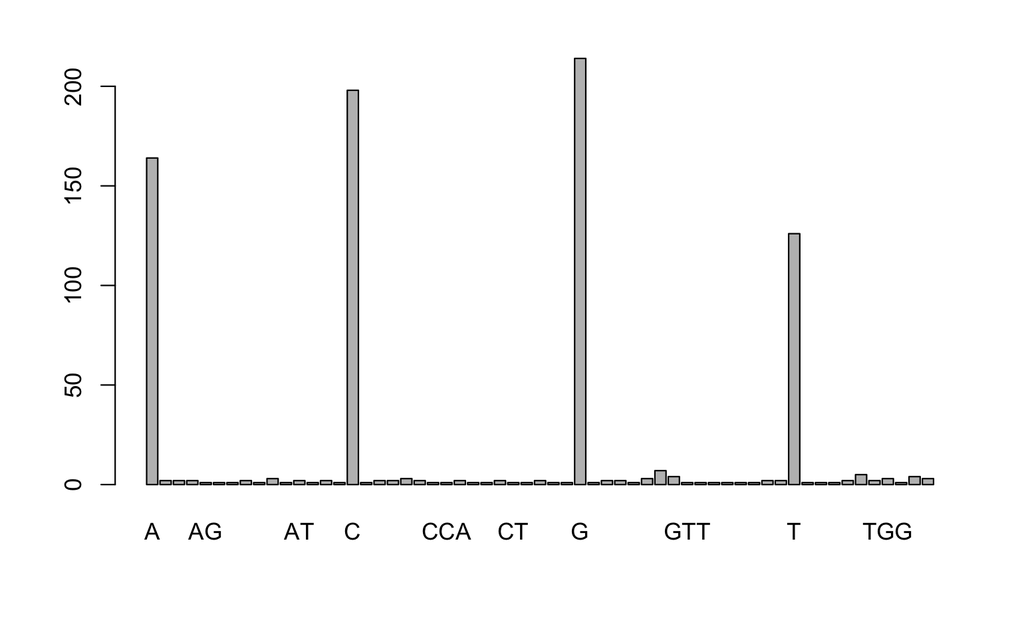

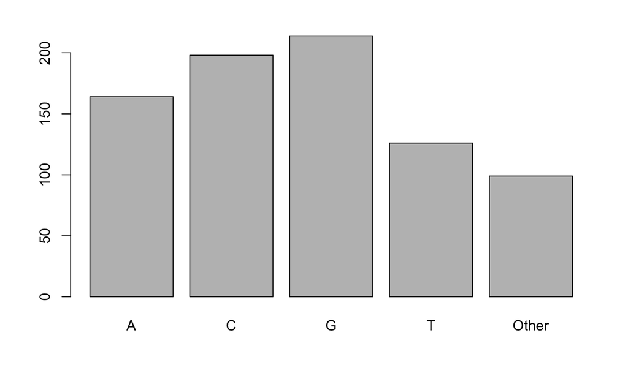

## Subsetting data frames

Next, we are going to talk about how you can get specific values from data frames,

and where necessary, change the mode of a column of values.

The subsetting notation is very similar to what we learned for vectors.

The key differences include:

Typically provide two values separated by commas: data.frame[row, column]

variants[1,1]

In cases where you are taking a continuous range of numbers use a colon between the numbers (start:stop, inclusive)

variants[1:5,1:5]

For a non continuous set of numbers, pass a vector using c() variants[c(1,4,9),1:5]

Index using the name of a column(s) by passing them as vectors using c() variants[1:5,c(“POS”)]

Finally, in all of the subsetting exercises above, we printed values to the screen. You can create a new data frame object by assigning them to a new object name

# create a new data frame from variants object containing only observations from sample_id SRR2584863

```r
SRR2584863_variants <-variants[variants$sample_id=="SRR2584863",]
```

check the dimension of the data frame ?dim()

```r
dim(SRR2584863_variants)
```

[output not shown]

## get a summary of the data frame ?summary()

```r
summary(SRR2584863_variants)
```

[output not shown]

#coercion #StringsAsFactors = FALSE

## Data frame bonus material: math, sorting, renaming

You can use functions like

mean() min() max()

on an individual column.

Find maximum depth, DP, of all variants

```r
max(variants$DP)
```

[output not shown]

You can sort a data frame using the order() function:

Sort variants data frame by DP

```r
sorted_by_DP <- variants[order(variants$DP), ]
head(sorted_by_DP$DP)
```

[output not shown]

You can rename columns: ?colnames

Rename column sample_id to strain

```r
colnames(variants)[colnames(variants) == "sample_id"] <- "strain"
```

check the column name (hint names are returned as a vector)

```r
colnames(variants)
```

[output not shown]

## Saving your data frame to a file

?write.csv() ?file.path()

```r
write.csv(x = SRR2584863_variants, file = file.path("data","SRR2584863_variants.csv"))
```

# Key Points

- It is easy to import data into R from tabular formats However, you still need to check that R has imported and interpreted your data correctly

There are best practices for organizing your data (keeping it tidy) and R is great for this Base R has many useful functions for manipulating your data, but all of R’s capabilities are greatly enhanced by software packages developed by the community

Swirl exercises data frames and factors